# Fig5B. Ketone bodies

Xuan He

October 17, 2024

# Clean up the environment

```r
rm(list = ls())
```

# Load library

```r
library(readxl)       # For reading Excel files
library(ggpubr)       # For creating publication-ready plots
library(dplyr)        # For data manipulation
library(tidyr)        # For reshaping data, replacing melt() from reshape2
library(ggh4x)        # For advanced faceting functions in ggplot2
library(rstatix)      # For statistical tests and adding significance markers
library(knitr)        # For displaying tibbles in a nice table format
library(kableExtra)   # For enhancing table formatting
```

# Load data

```r
# Load targeted serum and liver data
Serum <- read_excel("Data/Data.xlsx", sheet = "Nec_serum_targeted")
Liver <- read_excel("Data/Data.xlsx", sheet = "Liver_targeted")

# Load pig information and necropsy metadata
PigInfo <- read_excel("Data/Data.xlsx", sheet = "PigInfo")
Nec_metadata <- read_excel("Data/Data.xlsx", sheet = "Nec_metadata")
```

# Data organization

```r
# Define the list of metabolites for each sample type
ls.serum.metabolites <- c("3-Hydroxybutyrate", "Acetoacetate")
ls.liver.metabolites <- c("3-Hydroxybutyrate")
```

```r
Data.serum <- inner_join(Serum, PigInfo, by = "PigID") %>%
                select(Diet, all_of(ls.serum.metabolites)) %>%
                mutate(Region = "Serum") %>%
                pivot_longer(cols = all_of(ls.serum.metabolites), names_to = "variable", values_to = "value")


Data.liver <- inner_join(Liver, PigInfo, by = "PigID") %>%
                select(Diet, all_of(ls.liver.metabolites)) %>%
                mutate(Region = "Liver") %>%
                pivot_longer(cols = all_of(ls.liver.metabolites), names_to = "variable", values_to = "value")
```

```r
# Combine serum and liver data into a single dataset
All.data <- bind_rows(Data.serum, Data.liver) %>%
              mutate(Region = factor(Region, levels = c("Serum", "Liver")))
```

# Plotting data

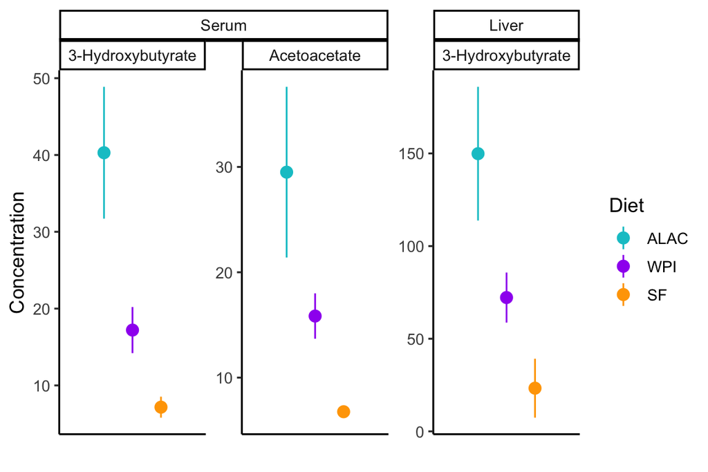

```r
Fig <- All.data %>%
        mutate(Diet = factor(Diet, levels = c("ALAC", "WPI", "SF"))) %>%
        ggerrorplot(x = "variable", y = "value", color = "Diet",
            palette = c("turquoise3", "purple", "orange"),
            na.rm = TRUE,
            xlab = "",
            ylab = "Concentration",
            add = "mean_se",
            size = 0.6,
            position = position_dodge(0.7)) +
            facet_nested(~Region + variable, scales = "free", independent = "y") +  # Free x axis with proportional facet widths using facet_nested
            theme_classic2() +
            theme(axis.text.x = element_blank(), axis.ticks.x = element_blank())


Fig
```

```r
# Save the figure in pdf format:
ggsave(plot=Fig, height=4, width=6, dpi=300, filename="Figure 5/Fig5B.pdf", useDingbats=FALSE)
```

# Group difference evaluation

```r
#This function transforms the input values by the generalized #log function.
glog <- function(y) {
  #Using lambda = 1
  yt <- log(y+sqrt(y^2+1))
  return(yt)
}
```

##ALAC vs WPI: Serum and liver data, adjusting for intake volume and postprandial time

```r
Serum %>% inner_join(PigInfo, by = "PigID") %>%
            inner_join(Nec_metadata, by = "PigID") %>%
            select(`3-Hydroxybutyrate`, `Acetoacetate`, Diet, SowID, Formula.consumed.g, Time.postprandial.min) %>%
            pivot_longer(cols = c(`3-Hydroxybutyrate`, `Acetoacetate`), names_to = "variable", values_to = "value") %>%
            filter(Diet %in% c("ALAC", "WPI")) %>%
            group_by(variable) %>%
            mutate(glog.value = glog(value * 10)) %>% # Apply generalized log transformation to metabolite values
            anova_test(glog.value ~ Diet + SowID + Formula.consumed.g + Time.postprandial.min, type = 1) %>% # Perform ANOVA
            add_significance(p.col = "p", cutpoints = c(0, 0.05, 0.1, 1), symbols = c("*", "#", "ns")) %>% # Add significance markers
            as_tibble() %>%
            filter(Effect == "Diet") %>%
            kable() %>% # Print the tibble in a nicely formatted table
            kable_styling(bootstrap_options = c("striped", "hover")) # Enhance table formatting with kableExtra
```

variable

Effect

DFn

DFd

F

p

p<.05

ges

p.signif

3-Hydroxybutyrate

Diet

1

17

16.933

0.000723

0.499

Acetoacetate

Diet

1

17

3.073

0.098000

0.153

#

```r
Liver %>% inner_join(PigInfo, by = "PigID") %>%
            inner_join(Nec_metadata, by = "PigID") %>%
            filter(Diet %in% c("ALAC", "WPI")) %>%
            mutate(glog.3HB = glog(`3-Hydroxybutyrate` * 10)) %>% # glog transformation
            anova_test(glog.3HB ~ Diet + SowID + Formula.consumed.g + Time.postprandial.min, type = 1)
```

```
## ANOVA Table (type I tests)
##
##                  Effect DFn DFd      F        p p<.05   ges
## 1                  Diet   1  17  8.665 9.00e-03     * 0.338
## 2                 SowID   2  17 17.317 7.92e-05     * 0.671
## 3    Formula.consumed.g   1  17  2.581 1.27e-01       0.132
## 4 Time.postprandial.min   1  17  1.582 2.26e-01       0.085
```

# Between formula-fed groups and SF, adjusting for sow ID

```r
Serum %>% inner_join(PigInfo, by = "PigID") %>%
            inner_join(Nec_metadata, by = "PigID") %>%
            select(`3-Hydroxybutyrate`, `Acetoacetate`, Diet, SowID) %>%
            pivot_longer(cols = c(`3-Hydroxybutyrate`, `Acetoacetate`), names_to = "variable", values_to = "value") %>%
            group_by(variable) %>%
            mutate(glog.value = glog(value * 10)) %>% # Apply generalized log transformation to metabolite values
            tukey_hsd(glog.value ~ Diet + SowID) %>% # Perform Tukey HSD test
            filter(term == "Diet") %>%
            add_significance(p.col = "p.adj", cutpoints = c(0, 0.05, 0.1, 1), symbols = c("*", "#", "ns")) %>%
            kable() %>% # Print the tibble in a nice table format
            kable_styling(bootstrap_options = c("striped", "hover")) # Enhance table formatting
```

variable

term

group1

group2

null.value

estimate

conf.low

conf.high

p.adj

p.adj.signif

3-Hydroxybutyrate

Diet

ALAC

SF

0

-1.4876968

-2.2638967

-0.7114968

0.000204

3-Hydroxybutyrate

Diet

ALAC

WPI

0

-0.7500827

-1.3884903

-0.1116751

0.019100

3-Hydroxybutyrate

Diet

SF

WPI

0

0.7376140

-0.0270860

1.5023141

0.060100

#

Acetoacetate

Diet

ALAC

SF

0

-1.1346856

-1.8158411

-0.4535301

0.000989

Acetoacetate

Diet

ALAC

WPI

0

-0.3770512

-0.9372868

0.1831845

0.233000

ns

Acetoacetate

Diet

SF

WPI

0

0.7576344

0.0865706

1.4286982

0.024800

```r
Liver %>% inner_join(PigInfo, by = "PigID") %>%
            inner_join(Nec_metadata, by = "PigID") %>%
            select(`3-Hydroxybutyrate`, Diet, SowID) %>%
            pivot_longer(cols = c(`3-Hydroxybutyrate`), names_to = "variable", values_to = "value") %>%
            group_by(variable) %>%
            mutate(glog.value = glog(value * 10)) %>%
            tukey_hsd(glog.value ~ Diet + SowID) %>%
            filter(term == "Diet") %>%
            add_significance(p.col = "p.adj", cutpoints = c(0, 0.05, 0.1, 1), symbols = c("*", "#", "ns")) %>%
            kable() %>% # Print the tibble in a nice table format
            kable_styling(bootstrap_options = c("striped", "hover")) # Enhance table formatting
```

variable

term

group1

group2

null.value

estimate

conf.low

conf.high

p.adj

p.adj.signif

3-Hydroxybutyrate

Diet

ALAC

SF

0

-4.4165417

-6.707699

-2.125384

0.000191

3-Hydroxybutyrate

Diet

ALAC

WPI

0

-0.5942223

-2.478650

1.290205

0.714000

ns

3-Hydroxybutyrate

Diet

SF

WPI

0

3.8223194

1.565107

6.079532

0.000832